# Week 2 Projections Exercises

We will continue to use this dataset:

```r
library(Biobase)
```

[output not shown]

SVD Exercises For the following questions use the data loaded with:

```r
library(tissuesGeneExpression)
data(tissuesGeneExpression)
```

Important note: When using the SVD in practice it is important to note that the solution to SVD is not unique. This is because 𝐔𝐃𝐕⊤=(−𝐔)𝐃(−𝐕)⊤. In fact we can flip the sign of each column of 𝐔 and as long as we also flip the respective column in 𝐕 the decompostion works. Here is R code demonstrating this:

```r
s = svd(e)
signflips = sample(c(-1,1),ncol(e),replace=TRUE)
signflips
```

```
  [1]  1 -1  1 -1  1  1  1 -1  1 -1  1 -1  1 -1  1
 [16] -1  1 -1  1  1 -1 -1  1 -1 -1 -1  1  1  1 -1
 [31] -1 -1 -1  1 -1  1 -1  1  1 -1 -1  1 -1 -1  1
 [46]  1  1 -1  1  1 -1  1  1  1  1 -1  1 -1 -1  1
 [61] -1 -1  1  1  1 -1 -1  1  1 -1 -1 -1  1 -1  1
 [76]  1 -1  1  1 -1  1 -1 -1  1  1  1  1  1 -1 -1
 [91]  1 -1  1  1 -1  1 -1  1  1 -1 -1 -1 -1  1 -1
[106] -1 -1  1  1 -1 -1  1 -1 -1 -1  1  1  1  1 -1
[121] -1  1  1 -1  1 -1 -1  1  1 -1 -1 -1  1 -1 -1
[136]  1 -1 -1  1  1 -1  1  1 -1 -1 -1 -1  1  1  1
[151]  1  1  1  1  1  1 -1 -1  1  1 -1 -1  1  1  1
[166]  1  1 -1  1  1  1 -1 -1 -1 -1 -1 -1  1 -1 -1
[181] -1  1  1 -1 -1 -1 -1 -1  1
```

Now we switch the sign of each column and check that we get the same answer. We do this using the function sweep(). If x is a matrix and a is a vector, then sweep(x,1,y,FUN="*") applies the function FUN to each row i FUN(x[i,],a[i]), in this case x[i,]*a[i]. If instead of 1 we use 2, sweep() applies this to columns. To learn about sweep(), read ?sweep.

```r
newu= sweep(s$u,2,signflips,FUN="*")
newv= sweep(s$v,2,signflips,FUN="*" )
all.equal( s$u %*% diag(s$d) %*% t(s$v), newu %*% diag(s$d) %*% t(newv))
```

```
[1] TRUE
```

This is important to know because different implementations of the SVD algorithm may give different signs, which can lead to the same code resulting in different answers when run in different computer systems.

SVD Exercises #1 1 point possible (graded) Compute the SVD of e:

```r
s = svd(e)
```

Now compute the mean of each row:

```r
m = rowMeans(e)
```

What is the correlation between the first column of 𝐔 and m?

```r
cor(s$u[,1],m)
```

```
[1] -0.9999998
```

SVD Exercises #2 1 point possible (graded) In the above question, we saw how the first column relates to the mean of the rows of e. Note that if we change these means, the distances between columns do not change. Here is some R code showing how changing the means does not change the distances:

```r
newmeans = rnorm(nrow(e)) ##random values we will add to create new means
newe = e+newmeans ##we change the means
sqrt(crossprod(e[,3]-e[,45]))
```

```
         [,1]
[1,] 152.5662
```

```r
sqrt(crossprod(newe[,3]-newe[,45]))
```

```
         [,1]
[1,] 152.5662
```

So we might as well make the mean of each row 0 since it does not help us approximate the column distances. We will define y as the detrended e and recompute the SVD:

```r
y = e - rowMeans(e)
s = svd(y)
```

We showed that 𝐔𝐃𝐕⊤ is equal to y up to numerical error:

```r
resid = y - s$u %*% diag(s$d) %*% t(s$v)
max(abs(resid))
```

```
[1] 1.188383e-12
```

The above can be made more efficient in two ways. First, using the crossprod() and second not creating a diagonal matrix. Note that in R we can multiply a matrix x by vector a. The result is a matrix with row i equal to x[i,]*a[i]. Here is an example to illustrate this.

```r
x=matrix(rep(c(1,2),each=5),5,2)
x
```

```
     [,1] [,2]
[1,]    1    2
[2,]    1    2
[3,]    1    2
[4,]    1    2
[5,]    1    2
```

```r
x*c(1:5)
```

```
     [,1] [,2]
[1,]    1    2
[2,]    2    4
[3,]    3    6
[4,]    4    8
[5,]    5   10
```

Note that the above code is actually equivalent to:

```r
sweep(x,1,1:5,"*")
```

```
     [,1] [,2]
[1,]    1    2
[2,]    2    4
[3,]    3    6
[4,]    4    8
[5,]    5   10
```

This means that we don’t have to convert s$d into a matrix to obtain 𝐃𝐕⊤.

SVD Exercises #4 1 point possible (graded) Let z = s$d * t(s$v). We showed a derivation demonstrating that because 𝐔 is orthogonal, the distance between e[,3] and e[,45] is the same as the distance between y[,3] and y[,45], which is the same as z[,3] and z[,45]:

```r
z = s$d * t(s$v)
sqrt(crossprod(e[,3]-e[,45]))
```

```
         [,1]
[1,] 152.5662
```

```r
sqrt(crossprod(y[,3]-y[,45]))
```

```
         [,1]
[1,] 152.5662
```

```r
sqrt(crossprod(z[,3]-z[,45]))
```

```
         [,1]
[1,] 152.5662
```

Note that the columns z have 189 entries, compared to 22,215 for e.

What is the difference (in absolute value) between the actual distance sqrt(crossprod(e[,3]-e[,45])) and the approximation using only two dimensions of z?

```r
realdistance = sqrt(crossprod(e[,3]-e[,45]))
approxdistance = sqrt(crossprod(z[1:2,3]-z[1:2,45]))
abs(realdistance - approxdistance)
```

```
         [,1]
[1,] 40.62416
```

SVD Exercises #5 1 point possible (graded) What is the minimum number of dimensions we need to use for the approximation in SVD Exercises #4 to be within 10% or less?

```r
ks = 1:189
realdistance = sqrt(crossprod(e[,3]-e[,45]))
approxdistances = sapply(ks,function(k){
    sqrt(crossprod(z[1:k,3,drop=FALSE]-z[1:k,45,drop=FALSE] ))
  })
percentdiff = 100*abs(approxdistances - realdistance)/realdistance
```

[output not shown]

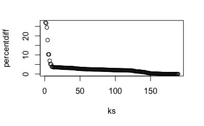

```r
plot(ks,percentdiff) ##take a look
```

```r
min(ks[which(percentdiff < 10)])
```

```
[1] 7
```

SVD Exercises #6 1 point possible (graded) Compute distances between sample 3 and all other samples:

```r
distances = sqrt(apply(e[,-3]-e[,3],2,crossprod))
```

Recompute this distance using the 2 dimensional approximation.

What is the Spearman correlation between this approximate distance and the actual distance?

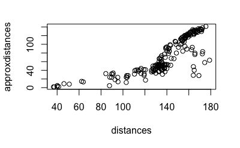

```r
approxdistances = sqrt(apply(z[1:2,-3]-z[1:2,3],2,crossprod))
plot(distances,approxdistances) ##take a look
```

```r
cor(distances,approxdistances,method="spearman")
```

```
[1] 0.8598592
```

Note that this shows how just two dimensions can be useful to get an idea about the actual distances.

MDS Exercises

For the following questions, use the data loaded with:

```r
library(tissuesGeneExpression)
data(tissuesGeneExpression)
```

MDS Exercises #1 1 point possible (graded) In these exercise we will demonstrate the relantionship between the SVD and the output of cmdscale(), the function in R that performs MDS.

Using the z we computed in SVD Exercises #4:

```r
y = e - rowMeans(e)
s = svd(y)
z = s$d * t(s$v)
```

we can make an MDS plot:

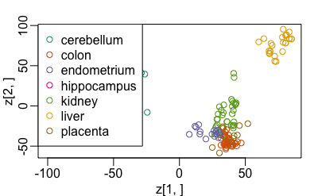

```r
library(rafalib)
ftissue = factor(tissue)
mypar(1,1)
plot(z[1,],z[2,],col=as.numeric(ftissue))
legend("topleft",levels(ftissue),col=seq_along(ftissue),pch=1)
```

Now run the function cmdscale() on the original data:

```r
d = dist(t(e))
mds = cmdscale(d)
```

What is the correlation between the first row of z and the first column in mds?

```r
cor(z[1,],mds[,1])
```

```
[1] -1
```

MDS Exercises #2 1 point possible (graded) What is the correlation between the second row of z and the second column of mds?

```r
cor(z[2,],mds[,2])
```

```
[1] -1
```

MDS Exercises #3 1 point possible (graded) Note that the MDS plot is not the same:

```r
library(rafalib)
ftissue = factor(tissue)
mypar(1,2)
plot(z[1,],z[2,],col=as.numeric(ftissue))
legend("topleft",levels(ftissue),col=seq_along(ftissue),pch=1)
```

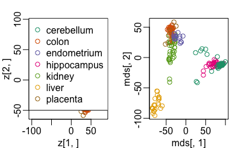

```r
plot(mds[,1],mds[,2],col=as.numeric(ftissue))
```

MDS Exercises #4 1 point possible (graded) Load the following dataset:

```r
library(GSE5859Subset)
```

[output not shown]

Compute the SVD and compute z:

```r
s = svd(geneExpression-rowMeans(geneExpression))
```

[output not shown]

[output not shown]

Which dimension of z most correlates with the outcome sampleInfo$group?

```r
which.max(cor(sampleInfo$g,t(z)))
```

[output not shown]

MDS Exercises #5 1/1 point (graded) Continue working with the z calculated from the GSE5859Subset data.

What is this max correlation?

```r
max(cor(sampleInfo$g,t(z)))
```

[output not shown]

MDS Exercises #6 1 point possible (graded) Continue working with the z calculated from the GSE5859Subset data.

Which dimension of z has the second highest correlation with the outcome sampleInfo$group?

```r
which.max(cor(sampleInfo$g,t(z))[-1]) + 1
```

[output not shown]

MDS Exercises #7 2 points possible (graded) Note these measurements were made during two months:

```r
sampleInfo$date
```

[output not shown]

We can extract the month this way:

```r
month = format( sampleInfo$date, "%m")
```

[output not shown]

```r
max(cor( as.numeric(month), t(z)))
```

[output not shown]

What is this correlation?

```r
max(cor( as.numeric(month), t(z)))
table(sampleInfo$g,month)
```

[output not shown]

MDS Exercises #8 (ADVANCED) 1 point possible (graded) Note: this is an advanced question. Please feel free to research this question online.

Which chromosome looks different from the rest?

```r
result = split(s$u[,6],geneAnnotation$CHR)
```

[output not shown]